# CSCI 385 - Second Deliverable

Jamie Van Winckel

12/3/2020

# Introduction

In this portfolio deliverable I will compare voter turnout to voter laws in different states.

#### Prediction

It is possible to predict the voter turnout percentage of a state in a presidential election based on the state’s voter ID law.

This question matters because if it is possible to predict voter turnout based on voter ID law then it is possible to increase voter turnout by changing the voter ID law. Such a low amount of Americans vote every year, and after this 2020 election we saw a huge increase in voters. If there is a way to get as many Americans that voted this year to vote every year, it could have a real impact to get everyone’s voices heard.

If voter turnout is related to different voter laws, then my prediction will be a success. However, if there is no relation or not a strong enough relation then my prediction will be false.

There are five different voter ID laws in the United States. They come in four categories: photo and non-photo, and strict and non-strict.

- Photo ID requirements:
  - States with photo ID requirements mandate voters to bring a state-issued driver’s license, non-driver ID or voter card, US passport, or a military, tribal, student, or state employee card to the polls in order to vote.
- Non-Photo ID requirements:
  - Non-photo ID states allow voters to bring official government mailings or other recent documents that bear the voter’s name and address, like a utility or rent bill, pay-stub, or bank statement.
- Non-Strict requirements:
  - Non-strict states allow voters without the required documentation to cast a sworn affidavit or reasonable impediment declaration or to have a poll worker vouch for them in order to vote
- Strict requirements:
  - Strict states require voters to cast a provisional ballot and later provide additional proof of residency to their election officials in order for their vote to count.

The five different types of voter ID laws are listed below:

- No ID requirement
- Non-strict non-photo ID
- Non-strict photo ID
- Strict non-photo ID
- Strict photo ID These five types will be used to predict if voter turnout is affected by the voter laws of the state.

## Web Scraping

- I web scraped a website to get information on the population of people over 18 per state.

```r
voterInfo <- read_html("https://www.federalregister.gov/documents/2019/10/04/2019-21663/estimates-of-the-voting-age-population-for-2018")

voterInfo <- setNames(data.frame(cbind(
  html_text(html_nodes(voterInfo, ".border-right-single")),
  html_text(html_nodes(voterInfo, ".right"))
)), c("StateName", "PopulationOver18"))

voterInfo$PopulationOver18 <- as.numeric(gsub(",","",voterInfo$PopulationOver18))
voterInfo <- voterInfo[-1,]
voterInfo <- as_tibble(voterInfo)
head(voterInfo)
```

```
## # A tibble: 6 x 2
##   StateName     PopulationOver18
##   <chr>                    <dbl>
## 1 United States        253768092
## 2 Alabama                3798031
## 3 Alaska                  553622
## 4 Arizona                5528989
## 5 Arkansas               2310645
## 6 California            30567090
```

# Data Summary

This table has information per state about voting and election information. This is arguably one of the most important tables in this project.

```r
head(stateInfo)
```

```
##   State  StateName StateAbbr ElectoralVotes AllowsPartyRegistration VoterIDLaw
## 1     1    Alabama        AL              9                   FALSE          3
## 2     2     Alaska        AK              3                    TRUE          2
## 3     4    Arizona        AZ             11                   FALSE          4
## 4     5   Arkansas        AR              6                   FALSE          2
## 5     6 California        CA             55                    TRUE          1
## 6     8   Colorado        CO              9                    TRUE          2
##         VoterIDLawVerbose ClosedPrimary
## 1     Non-strict photo ID         FALSE
## 2 Non-strict non-photo ID         FALSE
## 3     Strict non-photo ID         FALSE
## 4 Non-strict non-photo ID         FALSE
## 5       No ID requirement         FALSE
## 6 Non-strict non-photo ID         FALSE
```

This table shows the population over 18 per state.

```r
head(voterInfo)
```

```
## # A tibble: 6 x 2
##   StateName     PopulationOver18
##   <chr>                    <dbl>
## 1 United States        253768092
## 2 Alabama                3798031
## 3 Alaska                  553622
## 4 Arizona                5528989
## 5 Arkansas               2310645
## 6 California            30567090
```

The next four tables have information per state about the eligible voting population and the turnout per presidential election from 2008 to 2020.

```r
head(voterTurnout2008)
```

```
##           State VEP.Total.Ballots.Counted VEP.Highest.Office VAP.Highest.Office
## 1 United States                    62.20%             61.60%             56.90%
## 2       Alabama                    61.00%             60.80%             58.40%
## 3        Alaska                    68.30%             68.00%             64.30%
## 4       Arizona                    57.40%             56.70%             49.10%
## 5      Arkansas                    52.90%             52.50%             50.00%
## 6    California                    61.70%             60.90%             49.50%
##   Total.Ballots.Counted Highest.Office Voting.Eligible.Population..VEP.
## 1             132609063      131304731                        213313508
## 2               2105622        2099819                          3454510
## 3                327341         326197                           479429
## 4               2320851        2293475                          4046075
## 5               1095958        1086617                          2071563
## 6              13743177       13561900                         22261504
##   Voting.Age.Population..VAP. Percent.Non.citizen
## 1                   230872030               8.40%
## 2                     3595708               2.20%
## 3                      507645               3.70%
## 4                     4673718              11.60%
## 5                     2174846               2.90%
## 6                    27411094              17.90%
```

```r
head(voterTurnout2012)
```

```
##           State VEP.Total.Ballots.Counted2012 VEP.Highest.Office2012
## 1 United States                        58.60%                 58.00%
## 2       Alabama                                               58.60%
## 3        Alaska                        58.90%                 58.70%
## 4       Arizona                        53.00%                 52.60%
## 5      Arkansas                        51.10%                 50.70%
## 6    California                        55.70%                 55.10%
##   VAP.Highest.Office2012 Total.Ballots.Counted2012 Highest.Office2012
## 1                 53.60%                 130292355          129070906
## 2                 56.00%                        NA            2074338
## 3                 55.30%                    301694             300495
## 4                 46.50%                   2323579            2306559
## 5                 47.70%                   1078548            1069468
## 6                 45.10%                  13202158           13038547
##   Voting.Eligible.Population.VEP2012 Voting.Age.Population.VAP2012
## 1                          222474111                     240957993
## 2                            3539217                       3707440
## 3                             511792                        543763
## 4                            4387900                       4959270
## 5                            2109847                       2242740
## 6                           23681837                      28913129
##   Percent.Non.citizen State.Abv
## 1               8.40%
## 2               2.60%        AL
## 3               3.80%        AK
## 4               9.90%        AZ
## 5               3.50%        AR
## 6              17.40%        CA
```

```r
head(voterTurnout2016)
```

```
##           State VEP.Total.Ballots.Counted2016 VEP.Highest.Office2016
## 1 United States                        60.10%                 59.20%
## 2       Alabama                        59.10%                 58.80%
## 3        Alaska                        61.50%                 61.00%
## 4       Arizona                        56.10%                 54.90%
## 5      Arkansas                        53.20%                 52.80%
## 6    California                        58.20%                 56.50%
##   VAP.Highest.Office2016 Total.Ballots.Counted2016 Highest.Office2016
## 1                 54.70%                 138846571          136753936
## 2                 56.30%                   2134061            2123372
## 3                 57.40%                    321271             318608
## 4                 48.90%                   2661497            2604657
## 5                 49.40%                   1137772            1130635
## 6                 47.00%                  14610509           14181595
##   Voting.Eligible.Population.VEP2016 Voting.Age.Population.VAP2016
## 1                          230931921                     250055734
## 2                            3609447                       3770142
## 3                             522679                        555367
## 4                            4740310                       5331034
## 5                            2140097                       2286625
## 6                           25104844                      30201571
##   Percent.Non.citizen State.Abv
## 1               8.30%
## 2               2.50%        AL
## 3               4.10%        AK
## 4               9.40%        AZ
## 5               3.80%        AR
## 6              16.40%        CA
```

```r
head(voterTurnout2020)
```

```
##           State Total.Ballots.Counted..Estimate.
## 1 United States                        159215664
## 2       Alabama                          2325000
## 3        Alaska                           360684
## 4       Arizona                          3420565
## 5      Arkansas                          1222924
## 6    California                         17400000
##   Vote.for.Highest.Office..President. VEP.Turnout.Rate
## 1                                  NA           66.50%
## 2                             2323282           63.10%
## 3                              358802           68.60%
## 4                             3385294           65.90%
## 5                             1217036           56.00%
## 6                                  NA           67.00%
##   Voting.Eligible.Population..VEP. Voting.Age.Population..VAP.
## 1                        239247182                   257605088
## 2                          3683055                     3837540
## 3                           525568                      551117
## 4                          5189000                     5798473
## 5                          2182375                     2331171
## 6                         25962648                    30783255
##   Percent.Non.citizen State.Abv
## 1               7.80%
## 2               2.30%        AL
## 3               3.40%        AK
## 4               8.90%        AZ
## 5               3.60%        AR
## 6              15.00%        CA
```

Below I am making a tibble that has information about the state’s voter ID laws, voter turnout information from 2012 and 2016 (so that I can make a prediction of voter turnout in 2016 based on 2012 turnout), and a new column of voter turnout in 2016 per state (I will use this column to compare with my prediction model).

```r
voterTurnout2016 <- voterTurnout2016 %>%
  mutate(turnoutPercent2016 = (Total.Ballots.Counted2016 / Voting.Eligible.Population.VEP2016) * 100)
turnout1216 <- inner_join(voterTurnout2016, voterTurnout2012, by = c("State" = "State"))
turnout1216 <- inner_join(stateInfo, turnout1216, by = c("StateName" = "State"))
head(turnout1216)
```

```
##   State  StateName StateAbbr ElectoralVotes AllowsPartyRegistration VoterIDLaw
## 1     1    Alabama        AL              9                   FALSE          3
## 2     2     Alaska        AK              3                    TRUE          2
## 3     4    Arizona        AZ             11                   FALSE          4
## 4     5   Arkansas        AR              6                   FALSE          2
## 5     6 California        CA             55                    TRUE          1
## 6     8   Colorado        CO              9                    TRUE          2
##         VoterIDLawVerbose ClosedPrimary VEP.Total.Ballots.Counted2016
## 1     Non-strict photo ID         FALSE                        59.10%
## 2 Non-strict non-photo ID         FALSE                        61.50%
## 3     Strict non-photo ID         FALSE                        56.10%
## 4 Non-strict non-photo ID         FALSE                        53.20%
## 5       No ID requirement         FALSE                        58.20%
## 6 Non-strict non-photo ID         FALSE                        71.90%
##   VEP.Highest.Office2016 VAP.Highest.Office2016 Total.Ballots.Counted2016
```

[output cut: 48 more lines]

```r
stateVoterTurnout2008 <- inner_join(stateInfo, voterTurnout2008, by = c("StateName" = "State"))
stateVoterTurnout2012 <- inner_join(stateInfo, voterTurnout2012, by = c("StateName" = "State"))
stateVoterTurnout2016 <- inner_join(stateInfo, voterTurnout2016, by = c("StateName" = "State"))
stateVoterTurnout2020 <- inner_join(stateInfo, voterTurnout2020, by = c("StateName" = "State"))
```

## Old Model

```r
model <- lm(turnoutPercent2016 ~ VoterIDLaw, data = stateVoterTurnout2016)
model
```

```
##
## Call:
## lm(formula = turnoutPercent2016 ~ VoterIDLaw, data = stateVoterTurnout2016)
##
## Coefficients:
## (Intercept)   VoterIDLaw
##      65.058       -1.409
```

```r
model$coefficients
```

```
## (Intercept)  VoterIDLaw
##   65.058165   -1.408509
```

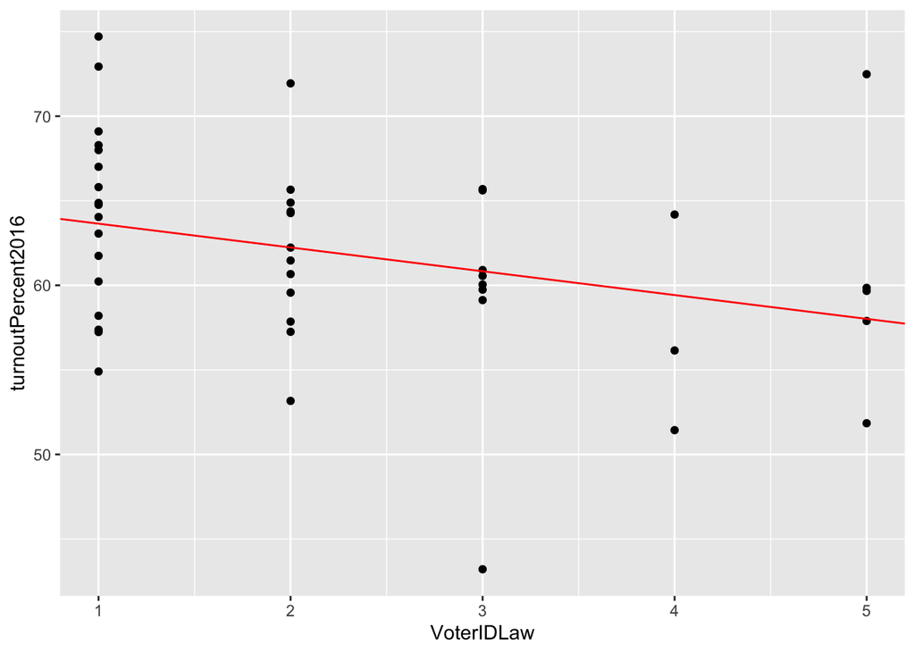

```r
ggplot(data = stateVoterTurnout2016, mapping = aes(x = VoterIDLaw, y = turnoutPercent2016)) +
  geom_point() +
  geom_abline(intercept = model$coefficients[1], slope = model$coefficients[2], color = "red")
```

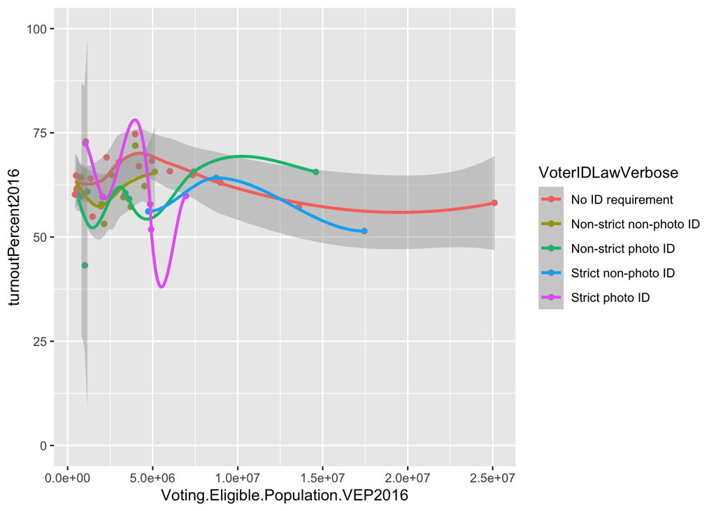

```r
ggplot(stateVoterTurnout2016, mapping = aes(x = Voting.Eligible.Population.VEP2016, y = turnoutPercent2016, color = VoterIDLawVerbose)) +
  geom_point(alpha = 1) +
  geom_smooth() +
  ylim(0,100)
```

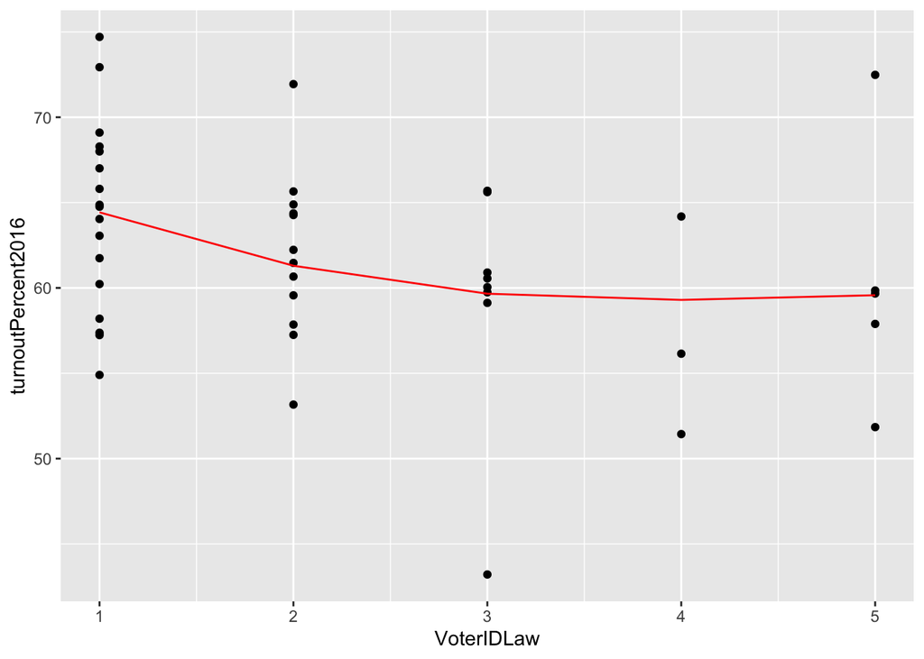

```r
model3 <- lm(turnoutPercent2016 ~ ns(VoterIDLaw, 2), data = stateVoterTurnout2016)

grid3 <- data_grid(stateVoterTurnout2016, VoterIDLaw) %>%
  add_predictions(model3)

data <- add_residuals(stateVoterTurnout2016, model3)

ggplot(data = data, mapping = aes(x = VoterIDLaw)) +
  geom_point(mapping = aes(y = turnoutPercent2016)) +
  geom_line(mapping = aes(y = pred), data = grid3, color = "red")
```

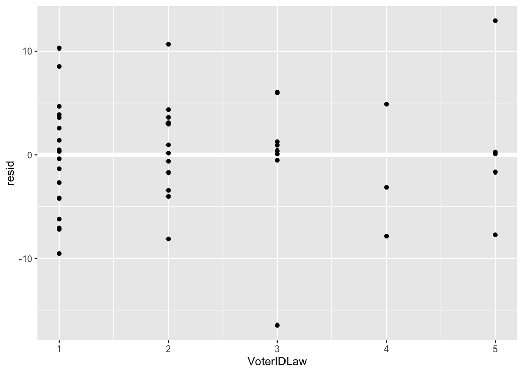

```r
ggplot(data = data, mapping = aes(x = VoterIDLaw, y = resid)) +
  geom_ref_line(h = 0) +
  geom_point()
```

This was my original model, but this does not work well. The first issue is that the variable VoterIDLaw is categorical, so it is hard to work with all together. I split up the tibble into five for each category (I have not included these models in the report). Another issue is that this linear model is using the voter law of that state to predict the turnout percent per state. This is far too simple. My model below uses numerous variables to predict voter turnout percent per state.

## MY MODEL

```r
turnout1216Untouched <- turnout1216
mymodel <- lm(turnoutPercent2016 ~ Voting.Age.Population.VAP2016 + Total.Ballots.Counted2012 + Voting.Eligible.Population.VEP2012 + VoterIDLawVerbose, data = turnout1216)
mymodel
```

```
##
## Call:
## lm(formula = turnoutPercent2016 ~ Voting.Age.Population.VAP2016 +
##     Total.Ballots.Counted2012 + Voting.Eligible.Population.VEP2012 +
##     VoterIDLawVerbose, data = turnout1216)
##
## Coefficients:
##                              (Intercept)
##                                6.279e+01
##            Voting.Age.Population.VAP2016
##                                1.882e-06
##                Total.Ballots.Counted2012
##                                1.661e-05
##       Voting.Eligible.Population.VEP2012
##                               -1.191e-05
## VoterIDLawVerboseNon-strict non-photo ID
##                               -1.947e+00
##     VoterIDLawVerboseNon-strict photo ID
##                               -6.460e+00
##     VoterIDLawVerboseStrict non-photo ID
##                               -4.557e+00
##         VoterIDLawVerboseStrict photo ID
##                               -1.295e+00
```

```r
mymodel$coefficients
```

```
##                              (Intercept)
##                             6.278515e+01
##            Voting.Age.Population.VAP2016
##                             1.882042e-06
##                Total.Ballots.Counted2012
##                             1.661008e-05
##       Voting.Eligible.Population.VEP2012
##                            -1.190895e-05
## VoterIDLawVerboseNon-strict non-photo ID
##                            -1.946706e+00
##     VoterIDLawVerboseNon-strict photo ID
##                            -6.459632e+00
##     VoterIDLawVerboseStrict non-photo ID
##                            -4.557466e+00
##         VoterIDLawVerboseStrict photo ID
##                            -1.294617e+00
```

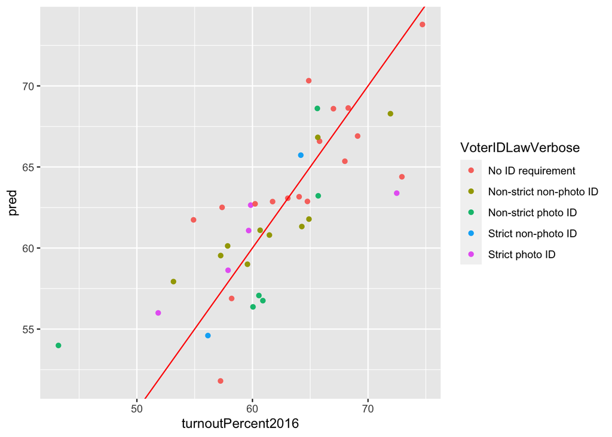

```r
turnout1216 <- add_predictions(turnout1216, mymodel)
ggplot(data = turnout1216, mapping = aes(x = turnoutPercent2016, y = pred, color = VoterIDLawVerbose)) +
  geom_point() +
  geom_abline(intercept = 0, slope = 1, color = "red")
```

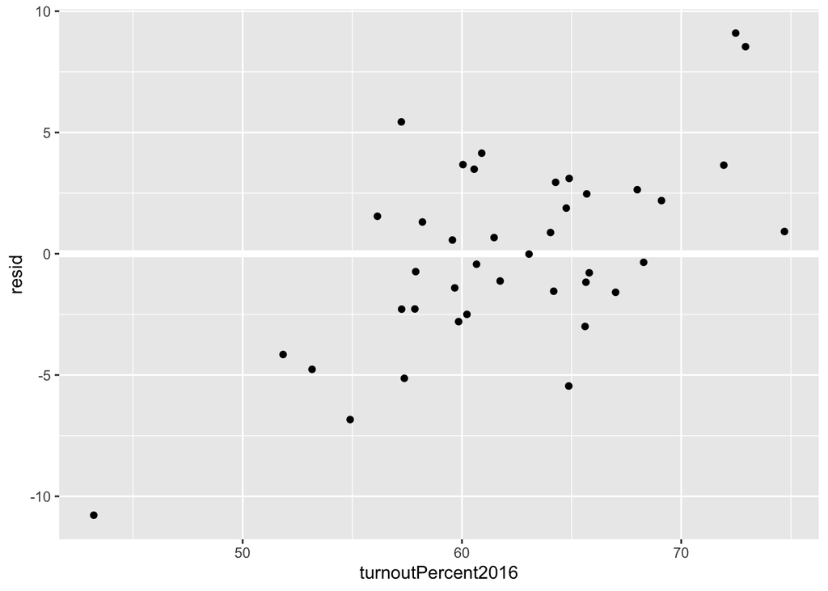

```r
turnout1216 <- add_residuals(turnout1216, mymodel)
ggplot(data = turnout1216, mapping = aes(x = turnoutPercent2016, y = resid)) +
  geom_ref_line(h = 0) +
  geom_point()
```

```r
one <- turnout1216Untouched %>%
  filter(VoterIDLaw == 1)
two <- turnout1216Untouched %>%
  filter(VoterIDLaw == 2)
three <- turnout1216Untouched %>%
  filter(VoterIDLaw == 3)
four <- turnout1216Untouched %>%
  filter(VoterIDLaw == 4)
five <- turnout1216Untouched %>%
  filter(VoterIDLaw == 5)
```

## No ID Requirement

```r
model1 <- lm(turnoutPercent2016 ~ Voting.Age.Population.VAP2016 + Total.Ballots.Counted2012 + Voting.Eligible.Population.VEP2012, data = one)
model1
```

```
##
## Call:
## lm(formula = turnoutPercent2016 ~ Voting.Age.Population.VAP2016 +
##     Total.Ballots.Counted2012 + Voting.Eligible.Population.VEP2012,
##     data = one)
##
## Coefficients:
##                        (Intercept)       Voting.Age.Population.VAP2016
##                          6.243e+01                           3.550e-07
##          Total.Ballots.Counted2012  Voting.Eligible.Population.VEP2012
##                          1.366e-05                          -8.268e-06
```

```r
model1$coefficients
```

```
##                        (Intercept)      Voting.Age.Population.VAP2016
##                       6.242544e+01                       3.549885e-07
##          Total.Ballots.Counted2012 Voting.Eligible.Population.VEP2012
##                       1.366422e-05                      -8.267522e-06
```

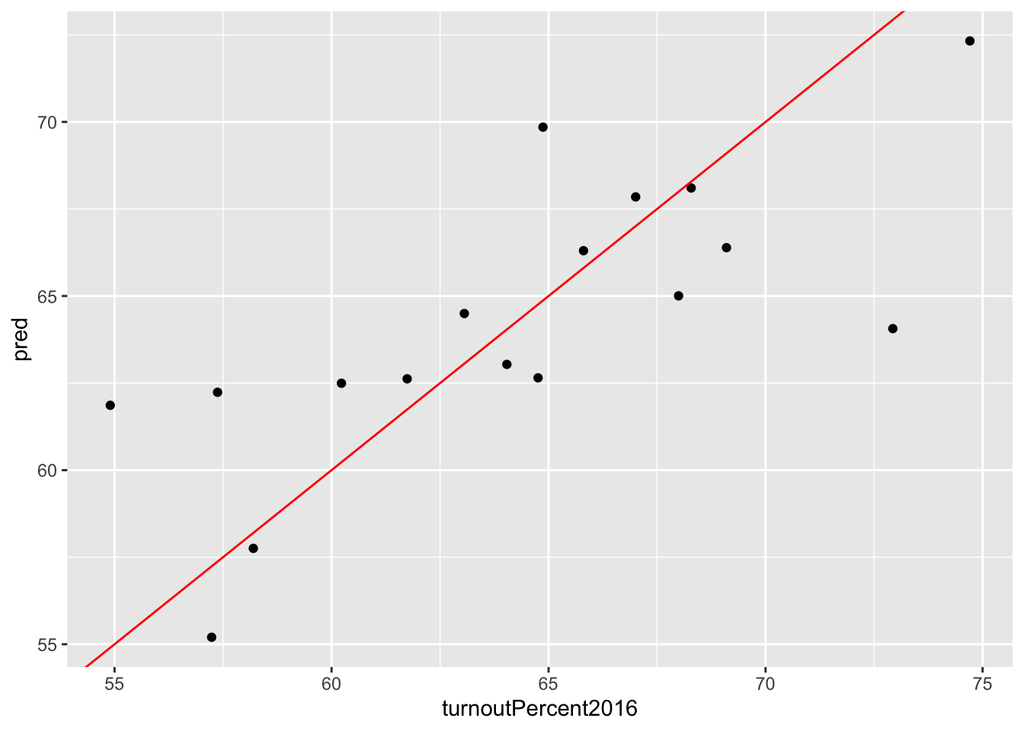

```r
one <- add_predictions(one, model1)
ggplot(data = one, mapping = aes(x = turnoutPercent2016, y = pred)) +
  geom_point() +
  geom_abline(intercept = 0, slope = 1, color = "red")
```

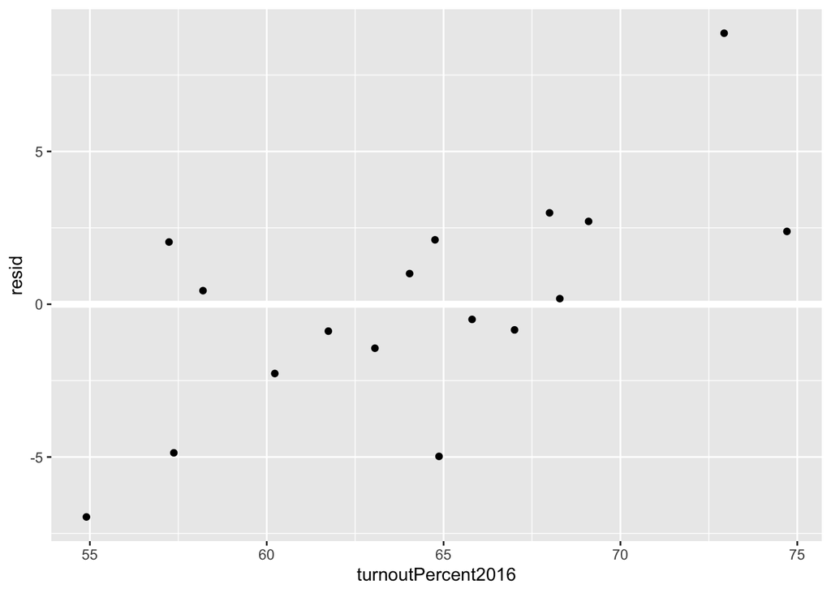

```r
one <- add_residuals(one, model1)
ggplot(data = one, mapping = aes(x = turnoutPercent2016, y = resid)) +
  geom_ref_line(h = 0) +
  geom_point()
```

## Non-strict non-photo ID

```r
model2 <- lm(turnoutPercent2016 ~ Voting.Age.Population.VAP2016 + Total.Ballots.Counted2012 + Voting.Eligible.Population.VEP2012, data = two)
model2
```

```
##
## Call:
## lm(formula = turnoutPercent2016 ~ Voting.Age.Population.VAP2016 +
##     Total.Ballots.Counted2012 + Voting.Eligible.Population.VEP2012,
##     data = two)
##
## Coefficients:
##                        (Intercept)       Voting.Age.Population.VAP2016
##                          6.177e+01                          -2.002e-05
##          Total.Ballots.Counted2012  Voting.Eligible.Population.VEP2012
##                          4.014e-05                          -1.929e-06
```

```r
model2$coefficients
```

```
##                        (Intercept)      Voting.Age.Population.VAP2016
##                       6.176953e+01                      -2.002191e-05
##          Total.Ballots.Counted2012 Voting.Eligible.Population.VEP2012
##                       4.013783e-05                      -1.928925e-06
```

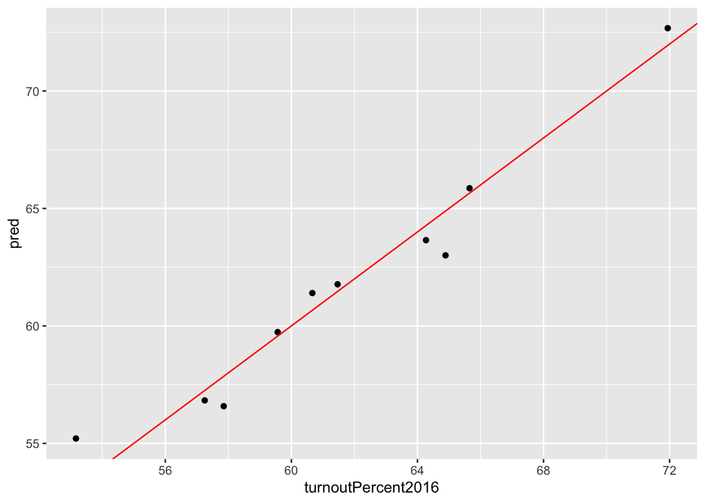

```r
two <- add_predictions(two, model2)
ggplot(data = two, mapping = aes(x = turnoutPercent2016, y = pred)) +
  geom_point() +
  geom_abline(intercept = 0, slope = 1, color = "red")
```

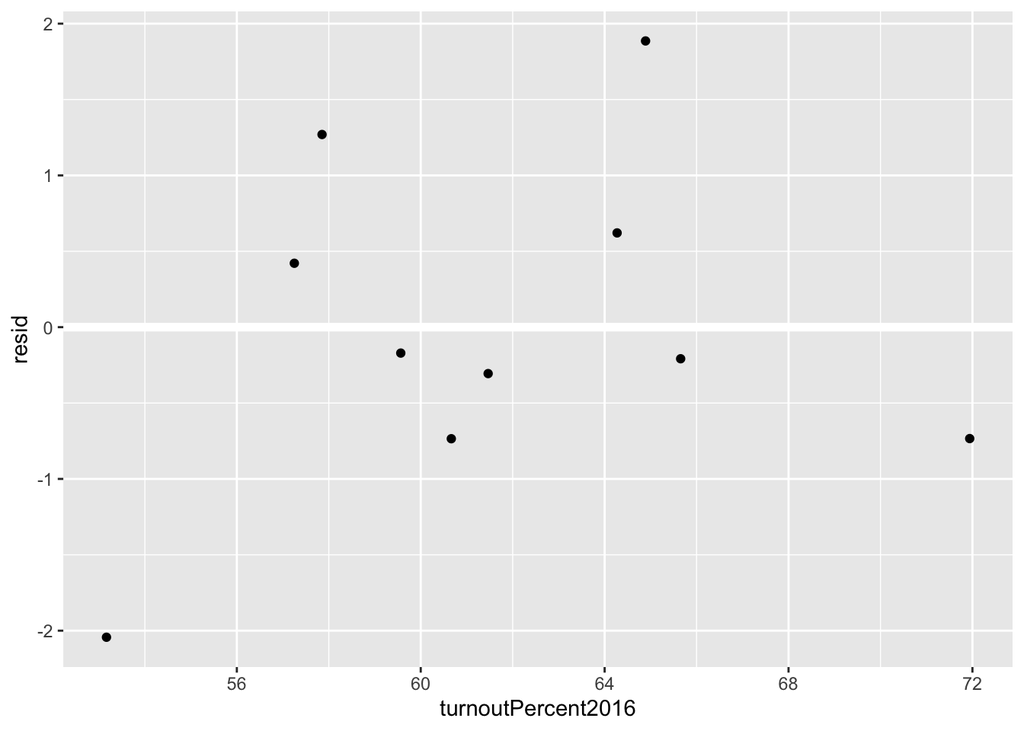

```r
two <- add_residuals(two, model2)
ggplot(data = two, mapping = aes(x = turnoutPercent2016, y = resid)) +
  geom_ref_line(h = 0) +
  geom_point()
```

## Non-strict photo ID

```r
model3 <- lm(turnoutPercent2016 ~ Voting.Age.Population.VAP2016 + Total.Ballots.Counted2012 + Voting.Eligible.Population.VEP2012, data = three)
model3
```

```
##
## Call:
## lm(formula = turnoutPercent2016 ~ Voting.Age.Population.VAP2016 +
##     Total.Ballots.Counted2012 + Voting.Eligible.Population.VEP2012,
##     data = three)
##
## Coefficients:
##                        (Intercept)       Voting.Age.Population.VAP2016
##                          6.206e+01                           6.006e-06
##          Total.Ballots.Counted2012  Voting.Eligible.Population.VEP2012
##                          7.409e-05                          -5.398e-05
```

```r
model3$coefficients
```

```
##                        (Intercept)      Voting.Age.Population.VAP2016
##                       6.206000e+01                       6.005813e-06
##          Total.Ballots.Counted2012 Voting.Eligible.Population.VEP2012
##                       7.409307e-05                      -5.398346e-05
```

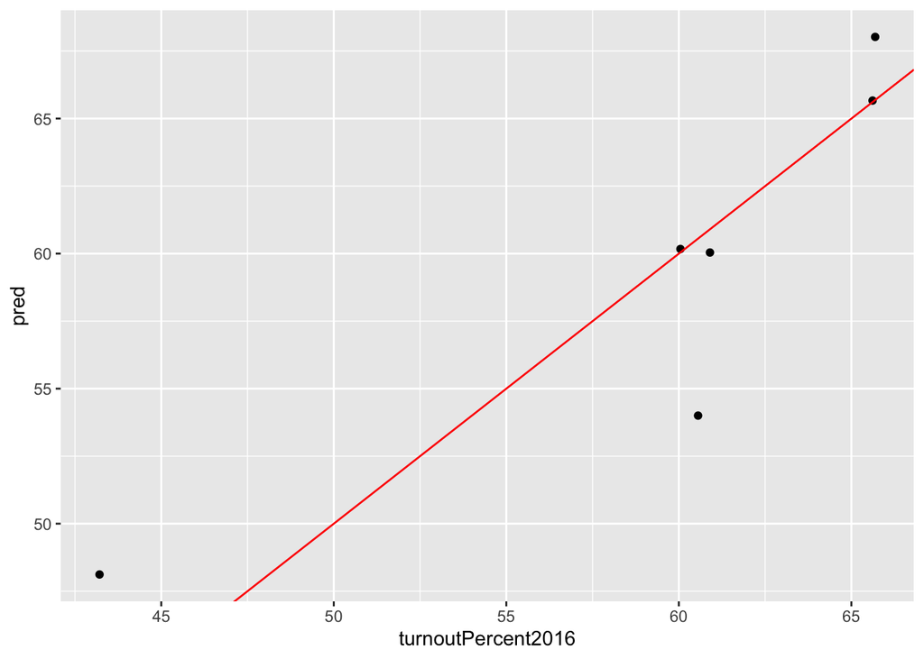

```r
three <- add_predictions(three, model3)
ggplot(data = three, mapping = aes(x = turnoutPercent2016, y = pred)) +
  geom_point() +
  geom_abline(intercept = 0, slope = 1, color = "red")
```

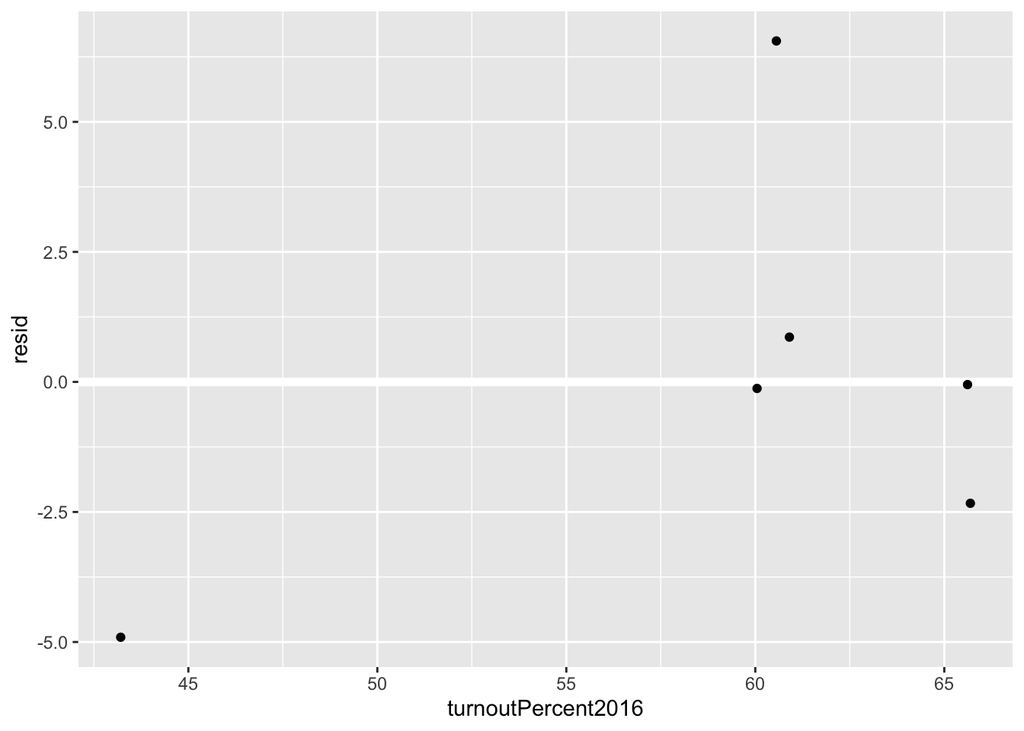

```r
three <- add_residuals(three, model3)
ggplot(data = three, mapping = aes(x = turnoutPercent2016, y = resid)) +
  geom_ref_line(h = 0) +
  geom_point()
```

## Strict non-photo ID

```r
model4 <- lm(turnoutPercent2016 ~ Voting.Age.Population.VAP2016 + Total.Ballots.Counted2012 + Voting.Eligible.Population.VEP2012, data = four)
model4
```

```
##
## Call:
## lm(formula = turnoutPercent2016 ~ Voting.Age.Population.VAP2016 +
##     Total.Ballots.Counted2012 + Voting.Eligible.Population.VEP2012,
##     data = four)
##
## Coefficients:
##                        (Intercept)       Voting.Age.Population.VAP2016
##                          4.449e+01                           2.186e-06
##          Total.Ballots.Counted2012  Voting.Eligible.Population.VEP2012
##                                 NA                                  NA
```

```r
model4$coefficients
```

```
##                        (Intercept)      Voting.Age.Population.VAP2016
##                       4.449199e+01                       2.186080e-06
##          Total.Ballots.Counted2012 Voting.Eligible.Population.VEP2012
##                                 NA                                 NA
```

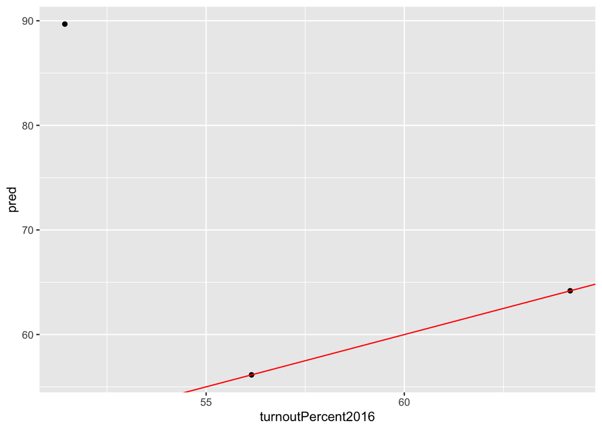

```r
four <- add_predictions(four, model4)
ggplot(data = four, mapping = aes(x = turnoutPercent2016, y = pred)) +
  geom_point() +
  geom_abline(intercept = 0, slope = 1, color = "red")
```

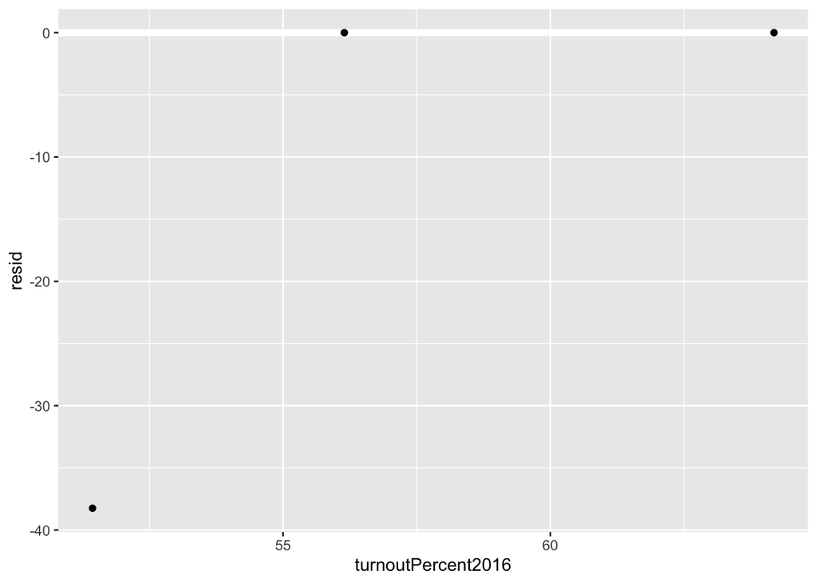

```r
four <- add_residuals(four, model4)
ggplot(data = four, mapping = aes(x = turnoutPercent2016, y = resid)) +
  geom_ref_line(h = 0) +
  geom_point()
```

## Strict photo ID

```r
model5 <- lm(turnoutPercent2016 ~ Voting.Age.Population.VAP2016 + Total.Ballots.Counted2012 + Voting.Eligible.Population.VEP2012, data = five)
model5
```

```
##
## Call:
## lm(formula = turnoutPercent2016 ~ Voting.Age.Population.VAP2016 +
##     Total.Ballots.Counted2012 + Voting.Eligible.Population.VEP2012,
##     data = five)
##
## Coefficients:
##                        (Intercept)       Voting.Age.Population.VAP2016
##                          6.491e+01                          -5.605e-06
##          Total.Ballots.Counted2012  Voting.Eligible.Population.VEP2012
##                          4.055e-05                          -1.817e-05
```

```r
model5$coefficients
```

```
##                        (Intercept)      Voting.Age.Population.VAP2016
##                       6.490790e+01                      -5.605310e-06
##          Total.Ballots.Counted2012 Voting.Eligible.Population.VEP2012
##                       4.054869e-05                      -1.817131e-05
```

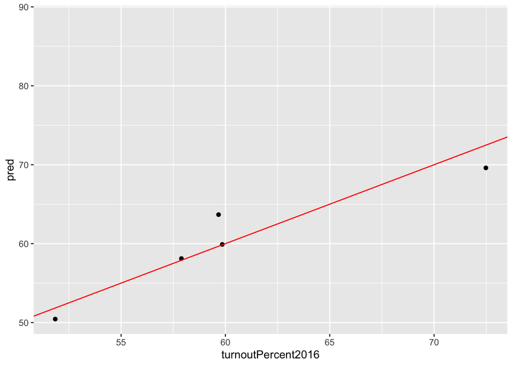

```r
five <- add_predictions(five, model5)
ggplot(data = five, mapping = aes(x = turnoutPercent2016, y = pred)) +
  geom_point() +
  geom_abline(intercept = 0, slope = 1, color = "red")
```

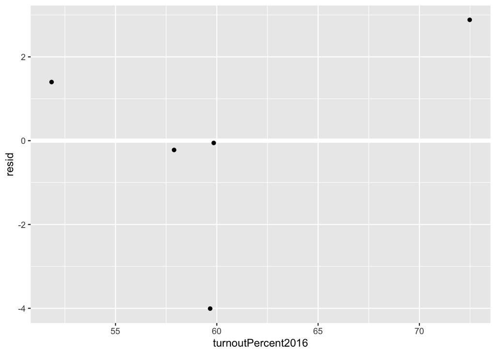

```r
five <- add_residuals(five, model5)
ggplot(data = five, mapping = aes(x = turnoutPercent2016, y = resid)) +
  geom_ref_line(h = 0) +
  geom_point()
```

In summary, all of these models are not extremely accurate. It looks like the variables that have been chosen are not the only direct causation to voter turnout. This does not mean that they do not play a factor. These models are not incorrect, they are just not telling the whole picture. There could be other factors like demographics per state or the friction of the political climate per presidential election.

I do not have any testing or validation set up yet. I did not realize we were supposed to have part of it done in this deliverable until the day this is due, but I will have all of it in Portfolio Project #3.

# Data Exploration

Various graphs to get to know my new data.

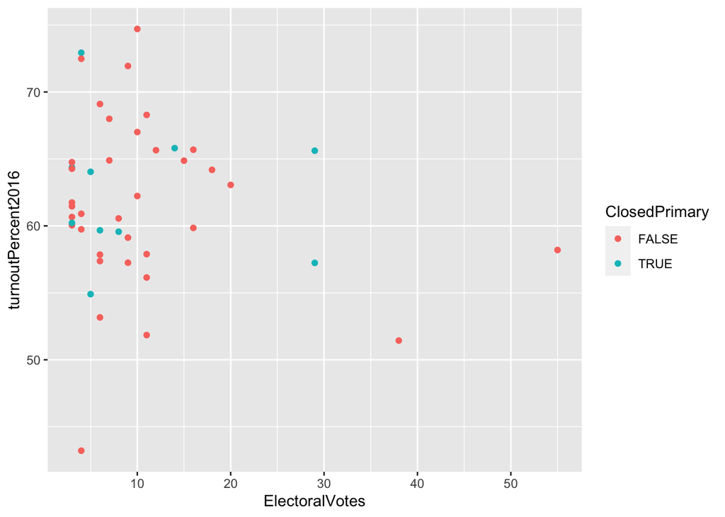

```r
ggplot(stateVoterTurnout2016, mapping = aes(x = ElectoralVotes, y = turnoutPercent2016, color = ClosedPrimary)) +
  geom_point(alpha = 1)
```

```r
stateVoterInfo <- inner_join(stateInfo, voterInfo, by = c("StateName" = "StateName"))
head(stateVoterInfo)
```

```
##   State  StateName StateAbbr ElectoralVotes AllowsPartyRegistration VoterIDLaw
## 1     1    Alabama        AL              9                   FALSE          3
## 2     2     Alaska        AK              3                    TRUE          2
## 3     4    Arizona        AZ             11                   FALSE          4
## 4     5   Arkansas        AR              6                   FALSE          2
## 5     6 California        CA             55                    TRUE          1
## 6     8   Colorado        CO              9                    TRUE          2
##         VoterIDLawVerbose ClosedPrimary PopulationOver18
## 1     Non-strict photo ID         FALSE          3798031
## 2 Non-strict non-photo ID         FALSE           553622
## 3     Strict non-photo ID         FALSE          5528989
## 4 Non-strict non-photo ID         FALSE          2310645
## 5       No ID requirement         FALSE         30567090
## 6 Non-strict non-photo ID         FALSE          4430329
```

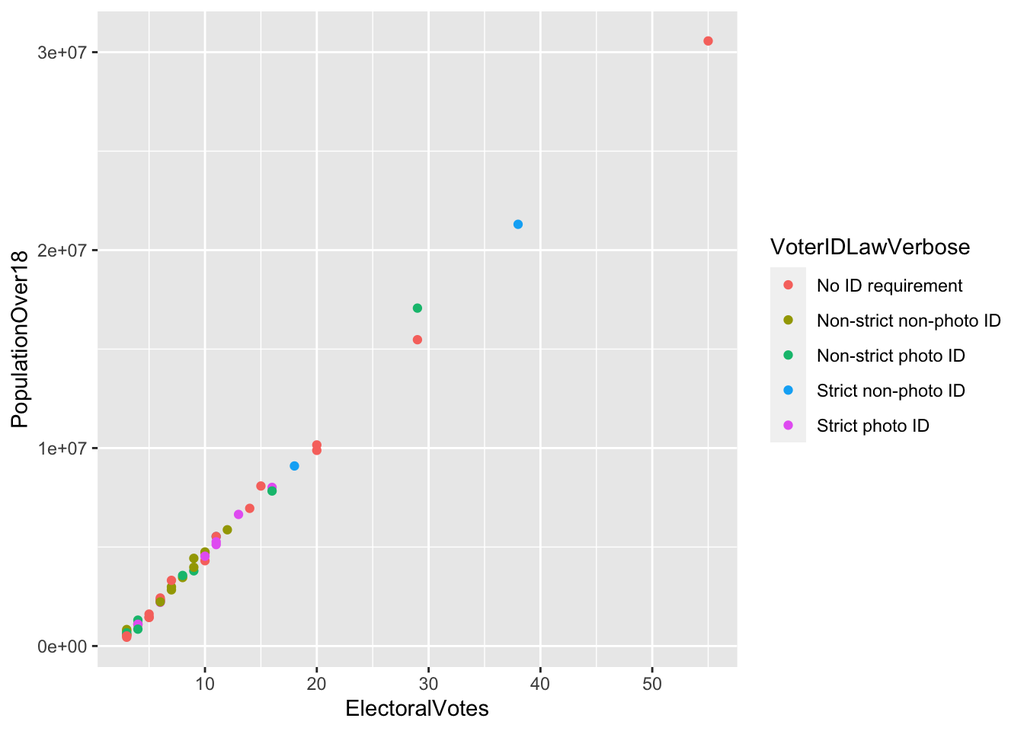

```r
ggplot(stateVoterInfo, mapping = aes(x = ElectoralVotes, y = PopulationOver18, color = VoterIDLawVerbose)) +
  geom_point(alpha = 1)
```

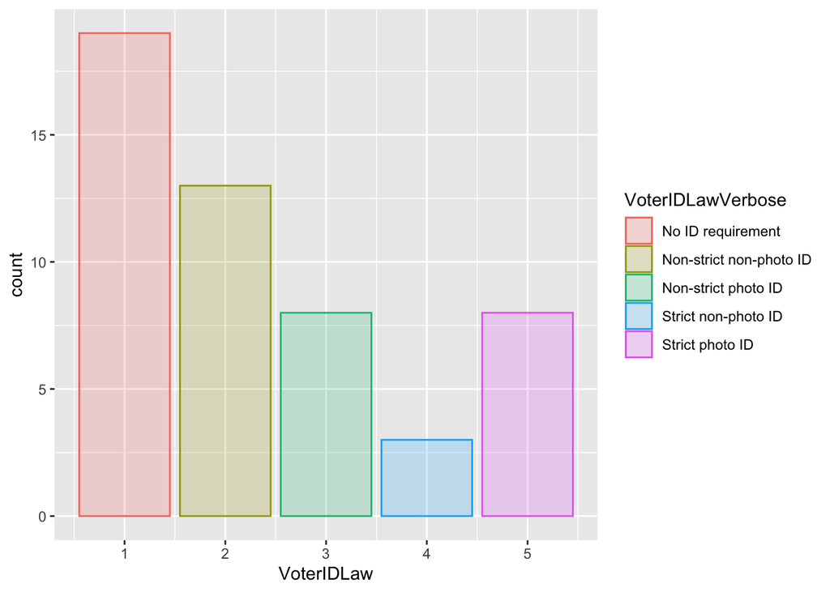

```r
ggplot(stateInfo, mapping = aes(x = VoterIDLaw, color = VoterIDLawVerbose)) +
  geom_bar(mapping = aes(fill = VoterIDLawVerbose), alpha = 0.2)
```

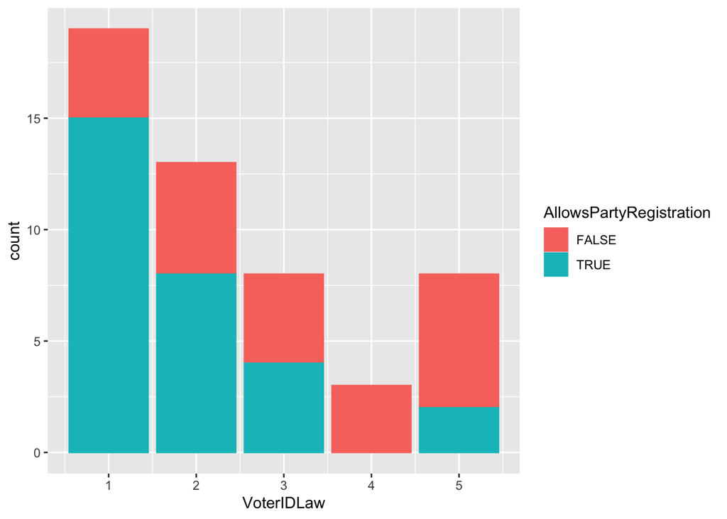

```r
ggplot(stateInfo, mapping = aes(x = VoterIDLaw, color = AllowsPartyRegistration)) +
  geom_bar(aes(fill = AllowsPartyRegistration))
```